# Capstone – Milestone Report

Yuling Tu

February 22, 2018

# Synopsis

The final goal of this project is to build a text prediction model in Shiny application by using the SwifKey data set.

The first step in building a predictive model for text is understanding the distribution and relationship between the words, tokens, and phrases in the sample text. The goal of this milestone report is to understand the basic relationships in the data and prepare to build the linguistic models.

# Data Exploratory and Cleaning

In this exploratory, only the English files are used.

## File Exploratory

The summary of data sets, including file sizes, line counts, word counts, median length of line, and maximum length of line, is listed below.

```r
## Loading the original data set
blogs <- readLines("./data/en_US.blogs.txt", encoding = "UTF-8", skipNul=TRUE)
news <- readLines("./data/en_US.news.txt", encoding = "UTF-8", skipNul=TRUE)
twitter <- readLines("./data/en_US.twitter.txt", encoding = "UTF-8", skipNul=TRUE)
## file size in MB
bsize <- file.info("./data/en_US.blogs.txt")$size/1024^2
nsize <- file.info("./data/en_US.news.txt")$size/1024^2
tsize <- file.info("./data/en_US.twitter.txt")$size/1024^2
## number of words
bword <- stri_count_words(blogs)
nword <- stri_count_words(news)
tword <- stri_count_words(twitter)

filedf <- data.frame(filename = c("blogs", "news", "twitter"),
           size_MB = c(bsize, nsize, tsize),
           num_lines = c(length(blogs), length(news), length(twitter)),
           num_words = c(sum(bword), sum(nword), sum(tword)),
           median_length = c(median(nchar(blogs)), median(nchar(news)), median(nchar(twitter))),
           #mean_length = c(mean(nchar(blogs)), mean(nchar(news)), mean(nchar(twitter))),
           max_length = c(max(nchar(blogs)), max(nchar(news)), max(nchar(twitter))))

filedf
```

```
##   filename  size_MB num_lines num_words median_length max_length
## 1    blogs 200.4242    899288  37546246           156      40833
## 2     news 196.2775     77259   2674536           186       5760
## 3  twitter 159.3641   2360148  30093410            64        140
```

## File Sampling

These files are huge, so only 5% of the data from each file are used for further analysis.

```r
set.seed(888)
bsample <- sample(blogs, length(blogs)*0.05, replace = FALSE)
nsample <- sample(news, length(news)*0.05, replace = FALSE)
tsample <- sample(twitter, length(twitter)*0.05, replace = FALSE)
## combine three sample together
allsample  <- c(bsample,nsample,tsample)
aline <- length(allsample)
aword <- sum(stri_count_words(allsample))
```

After sampling the data set, the combined sample data still have 166833 lines and 3508170 words. It’s still a good size of sample for next analysis.

## Data Cleaning

The tm package is used in this session to clean up the data. Before cleaning the data, corpus format is created from sampling file.

First, transform all characters to lowercase. Then, remove the numbers, the punctuation, and the excess white space. Finally, remove the common English stop-words (and, the, or etc..).

```r
# remove non-en characters
allsample <- iconv(allsample, "latin1", "ASCII", sub="")
# create corpus
allcorpus <- VCorpus(VectorSource(allsample))
#convert to lower case
allcorpus <- tm_map(allcorpus, content_transformer(tolower))
#remove all numbers
allcorpus <- tm_map(allcorpus, removeNumbers)
#remove all punctuation
allcorpus <- tm_map(allcorpus, removePunctuation)
#remove all white spaces
allcorpus <- tm_map(allcorpus, stripWhitespace)
# Remove stopwords
allcorpus <- tm_map(allcorpus, removeWords, stopwords("english"))
```

# N-Grams Analysis

Three N-Grams analysis listed below for the word trend analysis in sample files.

In the meantime, I choose to convert corpus to document-term matrix (DTM) or term-document matrix, which is a mathematical matrix that describes the frequency of terms that occur in a collection of documents. A DTM may helpful on improving search result or finding topics according to to Wikipedia.

In order to solve memory allocation issue during the sorting, I remove more than 0.99 percentage of empty (i.e., terms occurring 0 times in a document) elements.

## Uni-Grams Analysis

Both bar chart and word cloud chart are selected for plotting.

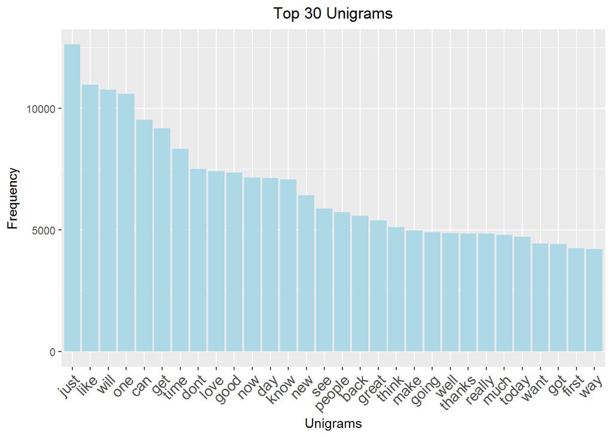

```r
uni<- function(x) {
        NGramTokenizer(x, Weka_control(min = 1, max = 1))
}
unigram <- removeSparseTerms(DocumentTermMatrix(allcorpus, control=list(tokenize=uni)), sparse=0.999)

unisort <- sort(colSums(as.matrix(unigram)), decreasing = TRUE)
unidf <- data.frame(word = names(unisort), frequency = unisort)
## ggplot of unigram
ggplot(unidf[1:30,], aes(reorder(word,-frequency), frequency))  +
    labs(x = "Unigrams", y = "Frequency") +
    ggtitle("Top 30 Unigrams") +
    theme(plot.title = element_text(hjust = 0.5)) +
    geom_bar(stat = "identity", fill = "lightblue") +
    theme(axis.text.x = element_text(angle = 45, size = 12, hjust = 1))
```

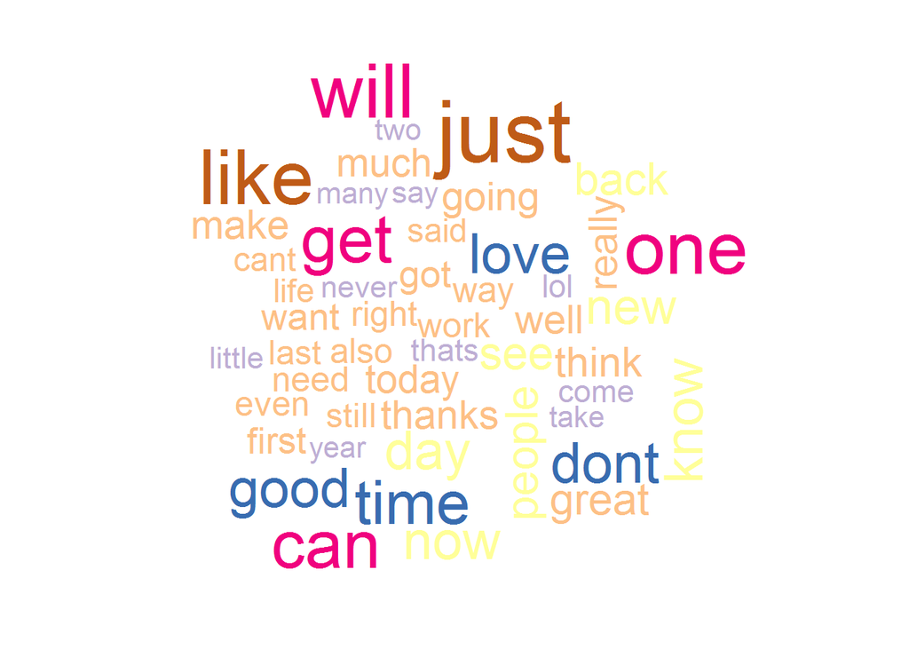

```r
## workcloud of unigram
wordcloud(names(unisort), unisort, max.words=50, colors=brewer.pal(7,"Accent"))
```

Uni-gram analysis is only displayed the word frequency, it’s definitely not the proper model for text perdition model.

## Bi-Grams Analysis

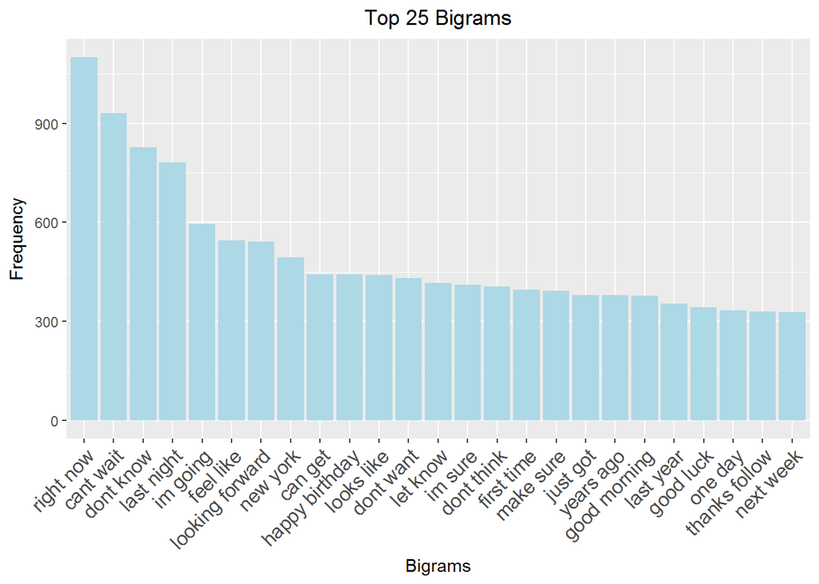

```r
bi <- function(x){NGramTokenizer(x, Weka_control(min = 2, max = 2))}
bigram <- removeSparseTerms(DocumentTermMatrix(allcorpus, control=list(tokenize=bi)), sparse=0.999)

bisort <- sort(colSums(as.matrix(bigram)),decreasing = TRUE)
bidf <- data.frame(word = names(bisort), frequency = bisort)
## ggplot of bigram
ggplot(bidf[1:25,], aes(reorder(word,-frequency), frequency))  +
    labs(x = "Bigrams", y = "Frequency") +
    ggtitle("Top 25 Bigrams") +
    theme(plot.title = element_text(hjust = 0.5)) +
    geom_bar(stat = "identity", fill = "lightblue") +
    theme(axis.text.x = element_text(angle = 45, size = 12, hjust = 1))
```

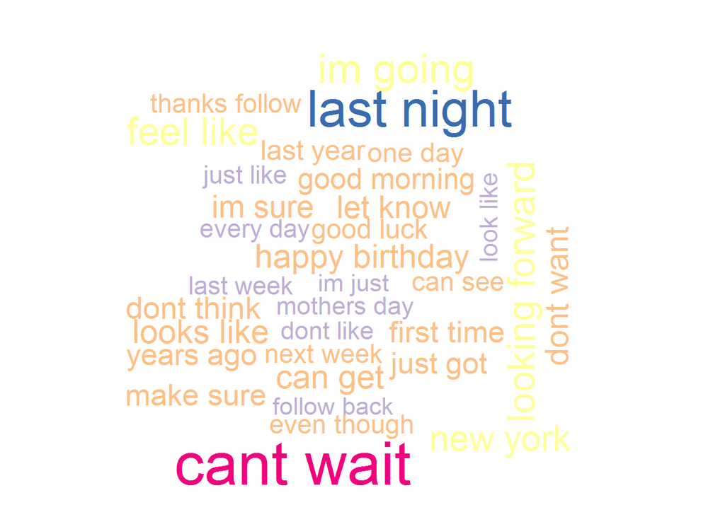

```r
## workcloud of bigram
wordcloud(names(bisort), bisort, max.words=35, colors=brewer.pal(7,"Accent"))
```

Bi-gram analysis show more interesting combination of how the word used. For example, like is highly frequent word in uni-gram, but many combinations in bi-gram. And, the combination of “like” has different meanings. Some of the meanings are totally opposite.

## Tri-Grams

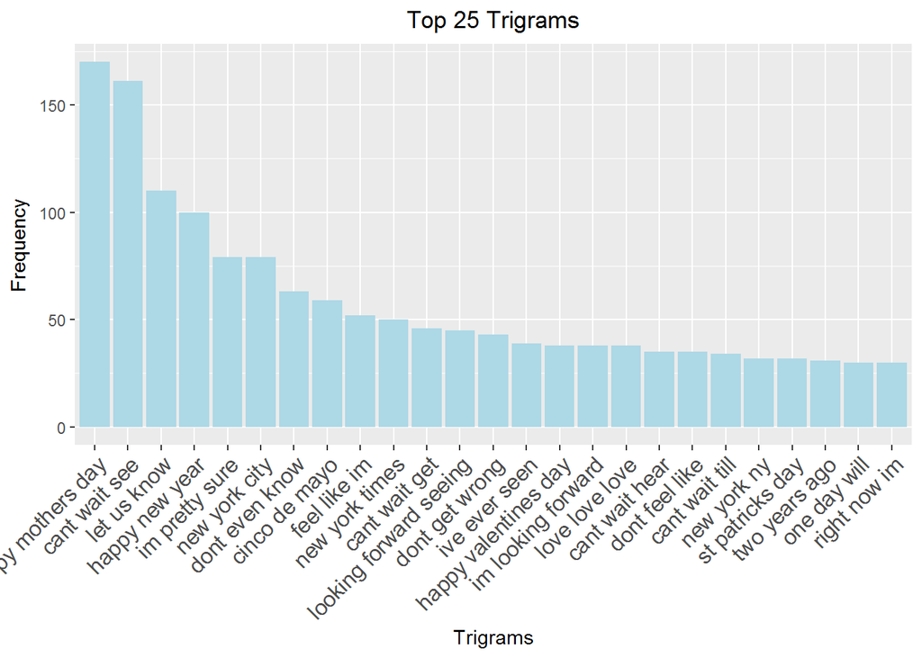

```r
tri <- function(x){NGramTokenizer(x, Weka_control(min = 3, max = 3))}
trigram <- removeSparseTerms(DocumentTermMatrix(allcorpus, control=list(tokenize=tri)), sparse=0.9999)

trisort <- sort(colSums(as.matrix(trigram)),decreasing = TRUE)
tridf <- data.frame(word = names(trisort), frequency = trisort)
## ggplot of trigram
ggplot(tridf[1:25,], aes(reorder(word,-frequency), frequency))  +
    labs(x = "Trigrams", y = "Frequency") +
    ggtitle("Top 25 Trigrams") +
    theme(plot.title = element_text(hjust = 0.5)) +
    geom_bar(stat = "identity", fill = "lightblue") +
    theme(axis.text.x = element_text(angle = 45, size = 12, hjust = 1))
```

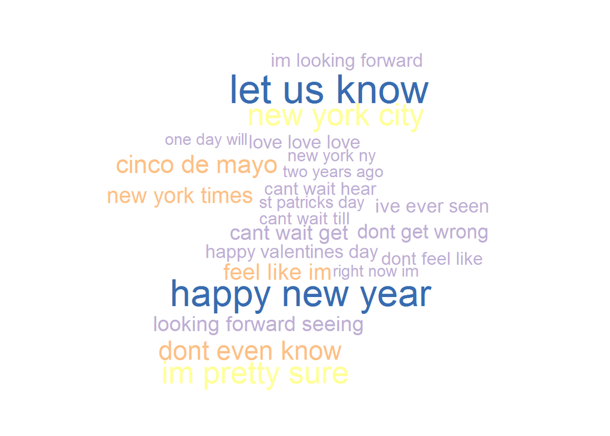

```r
## workcloud of bigram
wordcloud(names(trisort), trisort, max.words=25, colors=brewer.pal(7,"Accent"))
```

# Future Development Plan

### software

During the exploratory process, few issues has been identified.

– The tm package’s DocumentTermMatrix() process is very slow and memory intensive. Need to decrease sample size and add removeSparseTerms function to bypass the error.

– The tokenizer didn’t work with tm version 7.3. Need to install version 7 to fix the issue after lots of searching.

Researched on few forums, quanteda package is suggested. May try the new package on future assignments.

### Predition Model

Few items from the n-grams analysis can be considered for building the text prediction model.

– Quite of frequent used phases are apostrophe words. Would replace those apostrophe words into continuing words. For example, “cant to be”can not“.

– Remove more online URL, hash-tag related data.

– Remove repeated words, such as love love love.

– Explore more higher grams.

– Inlcude more sample data if new package can take process the load without error

– Create and test prediction algorithms with reasonable speed

– Create a Shiny application and presentation